# MA22019 - Combining data frames

12 February 2025

## Plan for Today

So far we have analyzed a single complex data frame using the dplyr R package.

Today we explore

- how we can combine multiple data frames;
- the elements of a plot
- visualizing data using ggplot2

## Combining Data Sets

## Motivation

Let’s revisit the river flow data for Bathford

```r
library(dplyr)
library(lubridate)
Bathford <- read.csv( "Bathford River Flow.csv", skip=20, header=FALSE,
                      colClasses = c("character","numeric","NULL") )  %>%
  rename( Date = V1, RiverFlow = V2 ) %>%
  mutate( Date = as_date( Date, format="%Y-%m-%d" ) )
glimpse( Bathford )
```

```
## Rows: 19,697
## Columns: 2
## $ Date      <date> 1969-10-27, 1969-10-28, 1969-10-29, 1969-10-30, 1969-10-31,…
## $ RiverFlow <dbl> 3.998, 3.958, 4.210, 4.480, 4.205, 3.830, 3.723, 3.986, 4.35…
```

## Reporting Missing Data

When we work with real-world data, we have to check whether data are missing.

If there is missing data, you should report the amount of missing data!

```r
Bathford %>%
  summarize( "Proportion Missing" = mean( is.na(RiverFlow) ) )
```

```
##   Proportion Missing
## 1        0.006244606
```

We see that river flow is missing for about 0.6% of days.

## Combining data sets with dplyr

**How can we add data from other gauges to the data frame?**

The dplyr package offers four functions to combine data frames based on matching values, which we call the “key(s)”.

- inner_join()
- full_join()
- left_join()
- right_join()

The functions differ in terms of observations kept.

## Example - Loading the data

Let’s load the river flow data for another gauge:

```r
Bath <- read.csv( "Bath River Flow.csv", skip=19, header=FALSE,
                  colClasses = c("character","numeric","NULL") )
Bath <- Bath %>% rename( Date = V1, RiverFlow = V2 ) %>%
  mutate( Date = as_date( Date, format="%Y-%m-%d" ) )
glimpse( Bath )
```

```
## Rows: 17,196
## Columns: 2
## $ Date      <date> 1976-09-01, 1976-09-02, 1976-09-03, 1976-09-04, 1976-09-05,…
## $ RiverFlow <dbl> 3.39, 2.83, 2.97, 2.81, 2.90, 2.81, 2.59, 3.11, 2.78, 2.46, …
```

## Example - Comparing the data sets

Let’s check the first elements of each data set

```r
slice_head( Bath, n=2 )
```

```
##         Date RiverFlow
## 1 1976-09-01      3.39
## 2 1976-09-02      2.83
```

```r
slice_head( Bathford, n=2 )
```

```
##         Date RiverFlow
## 1 1969-10-27     3.998
## 2 1969-10-28     3.958
```

**What do we notice?**

## Example - Merging the data sets

Let’s merge observations based on **Date**

```r
RF <- full_join( Bathford, Bath, by=c("Date" = "Date") )
slice_head(RF, n=1)
```

```
##         Date RiverFlow.x RiverFlow.y
## 1 1969-10-27       3.998          NA
```

We see that the variable names need updating:

```r
RF <- rename( RF, Bathford = RiverFlow.x, Bath = RiverFlow.y )
```

## Example - Data analysis

We explore dependence of the river flow levels

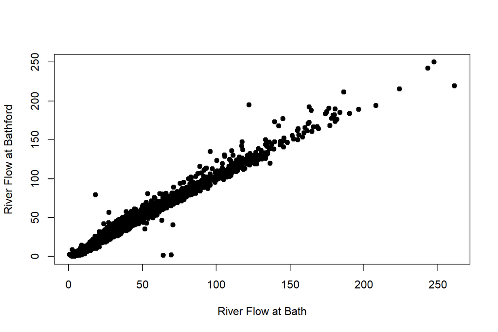

## Comparison with inner_join()

While full_join() keeps all observation, inner_join() only keeps the dates listed in both data sets

```r
RF <- inner_join( Bathford, Bath, by=c("Date" = "Date") )
slice_head(RF, n=3)
```

```
##         Date RiverFlow.x RiverFlow.y
## 1 1976-09-01       2.811        3.39
## 2 1976-09-02       2.560        2.83
## 3 1976-09-03       2.337        2.97
```

## Remarks

- left_join() and right_join()
- Combining a large number of data sets  
  -> **for loop** (Section 1.3.2)
- Order of elements after merging

```r
RF <- full_join( Bath, Bathford, by=c("Date" = "Date") )
slice_head( RF, n=1 )
```

```
##         Date RiverFlow.x RiverFlow.y
## 1 1976-09-01        3.39       2.811
```

## Key Messages

We have now finished the chapter on **Data Wrangling**. The take-home messages are

- Ensure that variables are of the correct type and use informative variable names
- Use the dplyr package to structure and manipulate your data
- The restructuring process should be determined by the research question
- Check for missing data and report the proportion if data are missing